# Kiosk Installation Guide (Ubuntu)

#### Pre-Installation Steps

- Enable any sort of auto power on functionality in the BIOS of the device now

#### Install Ubuntu LTS

- Set your keyboard layout to English (Australian)

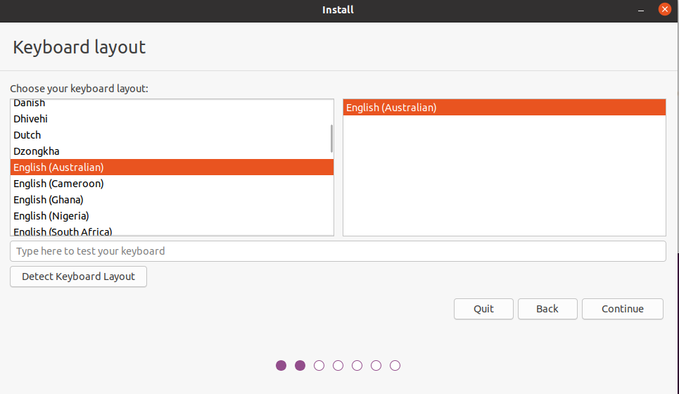

- Set the installation to minimal and check "install third-party software"

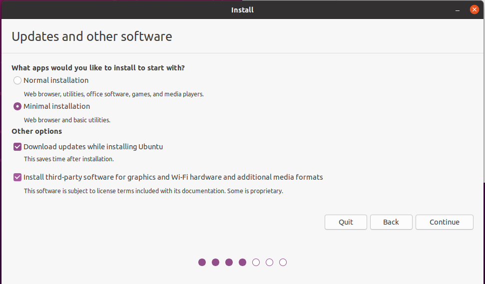

- Erase the disk and install ubuntu (should be default option unless you are reinstalling)

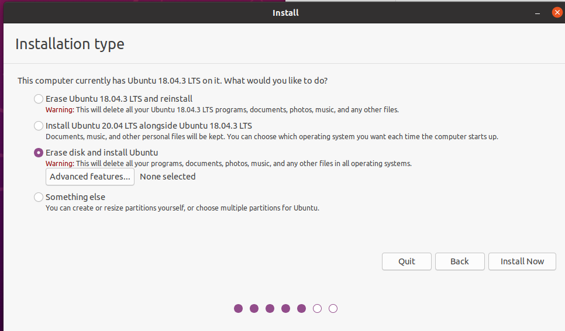

- Set the username and password to whatever you like, it will be changed by the installation script (you will need to know it for the script to run, however). Set your hostname to the convention cdc<state><task>-<asset number>. Task codes are as follows:
  - ws: workstation
  - sv: server
  - ks: kiosk
  - nb: notebook

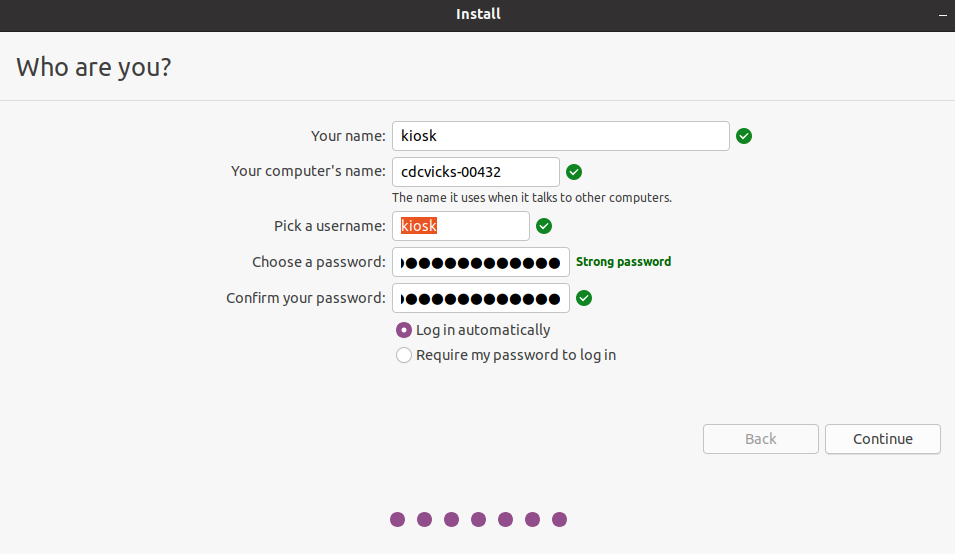

#### Post-Installation Steps

- Open up a terminal on the computer (`ctrl` + `alt` + `t`)
- install SSH with `sudo apt install openssh-server -y`
- Find out the IP of the system by running `ip a`
- You are now ready to run the main installation script